# Writeup

Marwa

12/20/2020

## synoposis

This report is to continue on the work of the research “Qualitative Activity Recognition of Weight Lifting Exercises” done by (Velloso, E.; Bulling, A.; Gellersen, H.; Ugulino, W.; Fuks, H.Read more: http://groupware.les.inf.puc-rio.br/har#ixzz6hCTkRqBE) The goal for this report is to train a model to predict if a person have done a correct set of movement in specific weight lifting Exercises. The data collected by a device such as Jawbone Up, Nike FuelBand, and Fitbit.

The data was collected from Six young healthy participants whom were asked to perform one set of 10 repetitions of the Unilateral Dumbbell Biceps Curl in five different fashions

The goal is to predict which classe the movement is categorized to Class A : exactly according to the specification . Class B : throwing the elbows to the front. Class C : lifting the dumbbell only halfway. Class D : lowering the dumbbell only halfway. Class E : throwing the hips to the front.

## Data Processing

```r
#downloading Data and creating  dataframes (train,test)
if (!file.exists("train.csv")) {
fileURL <- "https://d396qusza40orc.cloudfront.net/predmachlearn/pml-training.csv"
download.file(fileURL,destfile = "../MLP/train.csv",method = "curl")
}
train <- read.csv("train.csv")

if (!file.exists("test.csv")) {
fileURL <- "https://d396qusza40orc.cloudfront.net/predmachlearn/pml-testing.csv"
download.file(fileURL,destfile = "../MLP/test.csv",method = "curl")
}
test <- read.csv("test.csv")
```

## Training Model

```r
#Removing Zero Covariates
nsv <- nearZeroVar(train,saveMetrics = TRUE)
nsv
```

[output not shown]

[output cut: 106 more lines]

[output not shown]

```r
#taking only the variables of NZV = false as predictors
set.seed(22)
predictors <- which(nsv$nzv== FALSE)
cleanedData <- train[,predictors]
elements_2_remove = c("X", "user_name")
cleanedData = cleanedData[!(names(cleanedData) %in% elements_2_remove)]
intrain <-createDataPartition(y=cleanedData$classe,p=0.75,list=FALSE)
newtrain <- cleanedData[intrain,]
newtest <-cleanedData[-intrain,]

modfit <- train(classe ~ . ,method="rpart",data=newtrain,na.action=na.exclude)
print(modfit$finalModel)
```

```
## n= 302
##
## node), split, n, loss, yval, (yprob)
##       * denotes terminal node
##
## 1) root 302 220 A (0.27 0.2 0.16 0.17 0.2)
##   2) stddev_roll_belt< 1.35 247 166 A (0.33 0.24 0.19 0.18 0.053)
##     4) var_accel_dumbbell>=3.24695 46  11 B (0.087 0.76 0.022 0.022 0.11) *
##     5) var_accel_dumbbell< 3.24695 201 124 A (0.38 0.12 0.23 0.22 0.04) *
##   3) stddev_roll_belt>=1.35 55   8 E (0.018 0.018 0 0.11 0.85) *
```

```r
confusionMatrix(modfit)
```

```
## Bootstrapped (25 reps) Confusion Matrix
##
## (entries are percentual average cell counts across resamples)
##
##           Reference
## Prediction    A    B    C    D    E
##          A 20.7  7.8 11.8  7.1  1.9
##          B  2.6 10.1  0.9  1.4  2.4
##          C  1.2  0.3  1.7  0.6  0.2
##          D  2.5  1.7  1.2  5.6  0.5
##          E  0.3  0.6  0.0  2.0 15.0
##
##  Accuracy (average) : 0.5311
```

## plotting

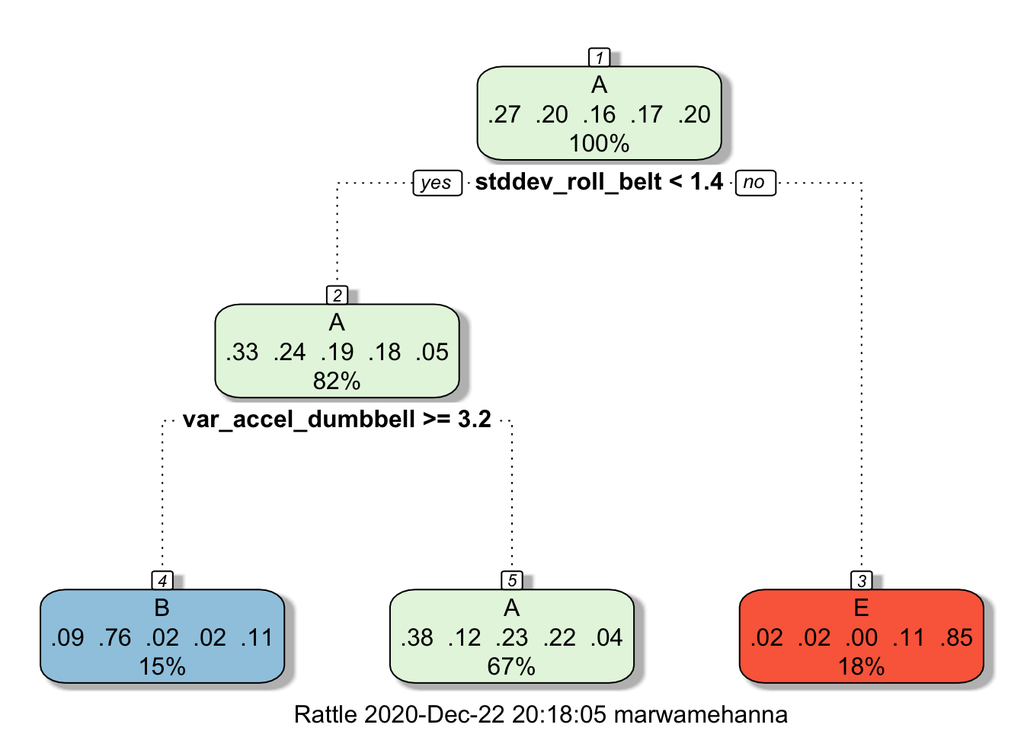

```r
fancyRpartPlot(modfit$finalModel)
```

## Trying different Model

```r
mod2fit <- train(classe ~ . ,method="rf",data=newtrain,Prox=TRUE,na.action=na.exclude)
print(mod2fit)
```

```
## Random Forest
##
## 14718 samples
##    97 predictor
##     5 classes: 'A', 'B', 'C', 'D', 'E'
##
## No pre-processing
## Resampling: Bootstrapped (25 reps)
## Summary of sample sizes: 302, 302, 302, 302, 302, 302, ...
## Resampling results across tuning parameters:
##
##   mtry  Accuracy   Kappa
##     2   0.7533369  0.6867961
##    58   0.7513733  0.6847761
##   115   0.7342578  0.6631629
##
## Accuracy was used to select the optimal model using the largest value.
## The final value used for the model was mtry = 2.
```

```r
confusionMatrix(mod2fit)
```

```
## Bootstrapped (25 reps) Confusion Matrix
##
## (entries are percentual average cell counts across resamples)
##
##           Reference
## Prediction    A    B    C    D    E
##          A 23.2  4.6  2.2  1.9  0.7
##          B  1.9 13.5  1.4  0.8  2.0
##          C  1.4  1.1 11.0  1.7  0.4
##          D  0.5  0.5  0.7 11.3  0.3
##          E  0.0  0.6  0.0  2.1 16.3
##
##  Accuracy (average) : 0.7534
```

```r
#Decision tree mean and standard deviation
mean(modfit$resample$Accuracy)
```

```
## [1] 0.533101
```

```r
sd(modfit$resample$Accuracy)
```

```
## [1] 0.07258013
```

```r
#Random Forest mean and standard deviation
mean(mod2fit$resample$Accuracy)
```

```
## [1] 0.7533369
```

```r
sd(mod2fit$resample$Accuracy)
```

```
## [1] 0.03380668
```

## Summary of the results

- The Random Forest model has the highest mean accuracy and lowest standard deviation,
- Decision tree model preforms the worst and has the highest standard deviation.

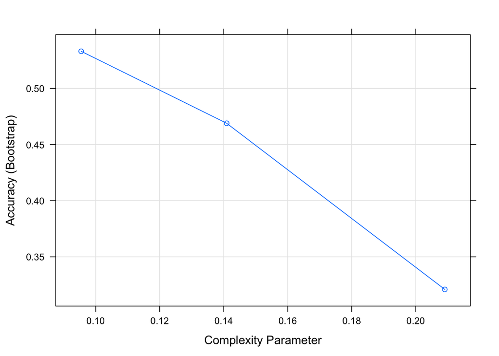

```r
plot(modfit)
```

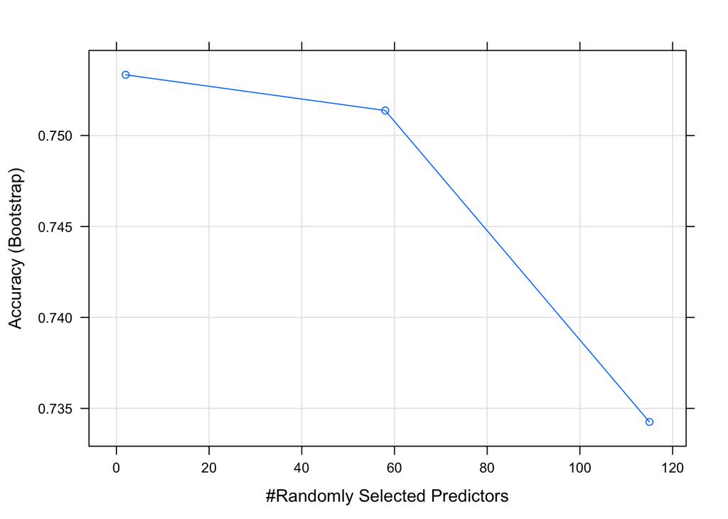

```r
plot(mod2fit)
```

## Prediction

```r
prediction1 <- predict(modfit, newtest)
prediction2 <- predict(mod2fit, newtest)
```